# Geo y Salud

# Pasos de frontera y migración

### Objetivo

El objetivo de este trabajo es indagar si existe una relación entre la ubicación de los migrantes y los pasos fronterizos. La hipótesis es que los inmigrantes se ubican en los radios censales de las ciudades que están cerca de los pasos fronterizos.

El trabajo tendrá dos momentos. Primero definiremos para cada radio censal la distancia entre su centroide y el paso fronterizo más cercano. Luego, veremos en qué radio censal se ubican más extranjeros.

Cargamos base de pasos de frontera.

```
## Simple feature collection with 6 features and 10 fields
## Geometry type: POINT
## Dimension:     XY
## Bounding box:  xmin: -65.59397 ymin: -29.73846 xmax: -53.7345 ymax: -22.06785
## Geodetic CRS:  WGS 84
## # A tibble: 6 x 11
##   nam         acc acc_lbl    zch zch_lbl   zts zts_lbl  zvf    codigo correccion
##   <chr>     <int> <chr>    <int> <chr>   <int> <chr>    <chr>  <chr>  <chr>
## 1 Aguas Bl~     2 Aproxim~     0 ""          1 Terrest~ Aguas~ BOL003 si
## 2 El Conda~     2 Aproxim~     0 ""          1 Terrest~ El Co~ BOL004 no
## 3 La Quiac~     2 Aproxim~     0 ""          6 Fluvial~ La Qu~ BOL005 si
## 4 Paso de ~     2 Aproxim~     0 ""          6 Fluvial~ Paso ~ BRA001 si
## 5 Santo To~     2 Aproxim~     0 ""          6 Fluvial~ Santo~ BRA005 si
## 6 Pepirí G~     2 Aproxim~     0 ""          1 Terrest~ Paraj~ BRA016 si
## # ... with 1 more variable: geometry <POINT [°]>
```

```
## [1] "sf"         "tbl_df"     "tbl"        "data.frame"
```

```
##      nam                 acc      acc_lbl               zch
##  Length:222         Min.   :2   Length:222         Min.   :0
##  Class :character   1st Qu.:2   Class :character   1st Qu.:0
##  Mode  :character   Median :2   Mode  :character   Median :0
##                     Mean   :2                      Mean   :0
##                     3rd Qu.:2                      3rd Qu.:0
##                     Max.   :2                      Max.   :0
##    zch_lbl               zts          zts_lbl              zvf
##  Length:222         Min.   :1.000   Length:222         Length:222
##  Class :character   1st Qu.:1.000   Class :character   Class :character
##  Mode  :character   Median :3.000   Mode  :character   Mode  :character
##                     Mean   :2.676
##                     3rd Qu.:3.000
##                     Max.   :6.000
##     codigo           correccion                 geometry
##  Length:222         Length:222         POINT        :222
##  Class :character   Class :character   epsg:4326    :  0
##  Mode  :character   Mode  :character   +proj=long...:  0
##
##
##
```

Graficamos de manera exploratoria los pasos de frontera.

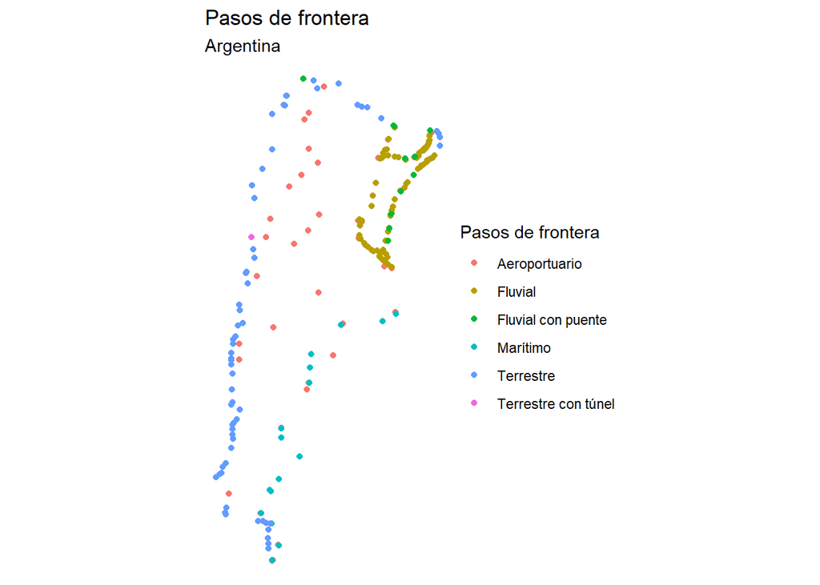

Cargamos los radios censales. Fuente: https://data.world/vazquez-brust/censo-argentino-2010

Obtenemos el centroide de cada radio.

Hacemos un plot exploratorio de los radios y los pasos fronterizos.

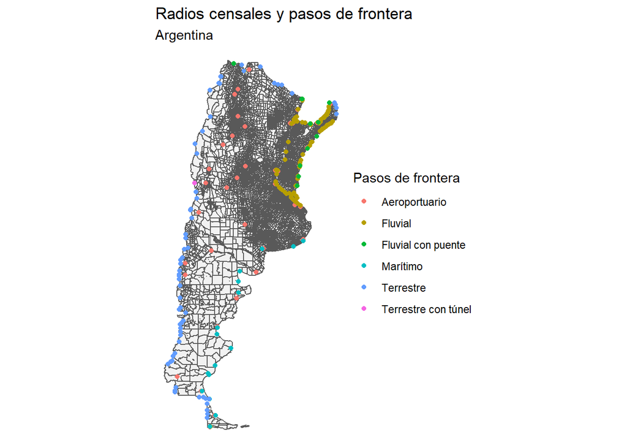

Calculamos la distancia entre el centroide del radio y el paso fronterizo más cercano. Cuidado! tarda bastante en realizar el cálculo.

Calculamos nuevamente la distancia pero con el dataset sin pasos fluviales. Por el análisis posterior, intuímos que puede haber una mejor relación con la población migrante si no tenemos en cuenta los pasos fronterizos fluviales.

```
## although coordinates are longitude/latitude, st_nearest_points assumes that they are planar
```

```
## [1] "Duracion celda (en minutos)"
```

```
##       user     system    elapsed
## 5.60483333 0.09083333 5.78700000
```

Veamos cómo queda el mapa argentino con ambas distancias.

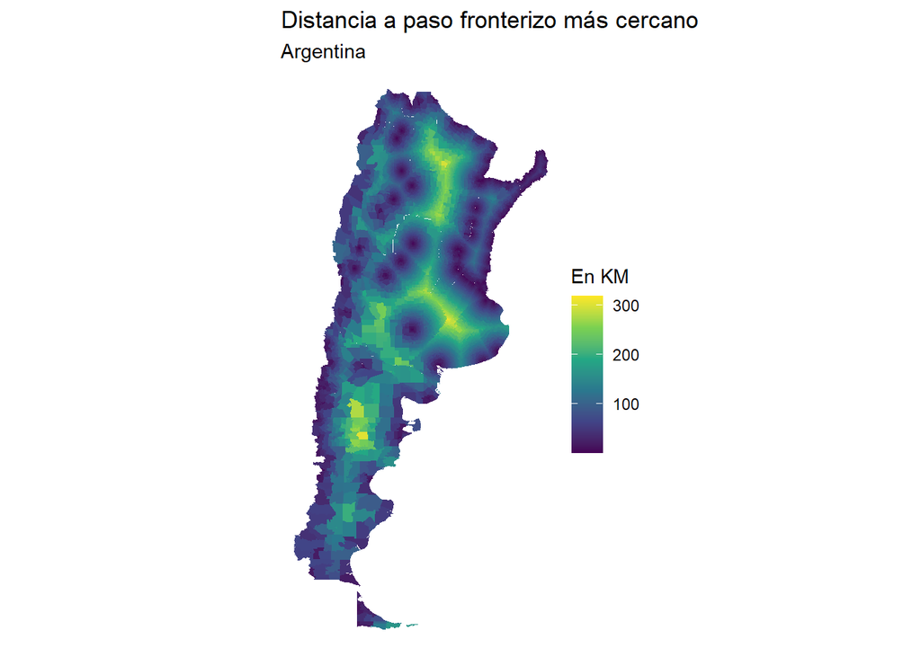

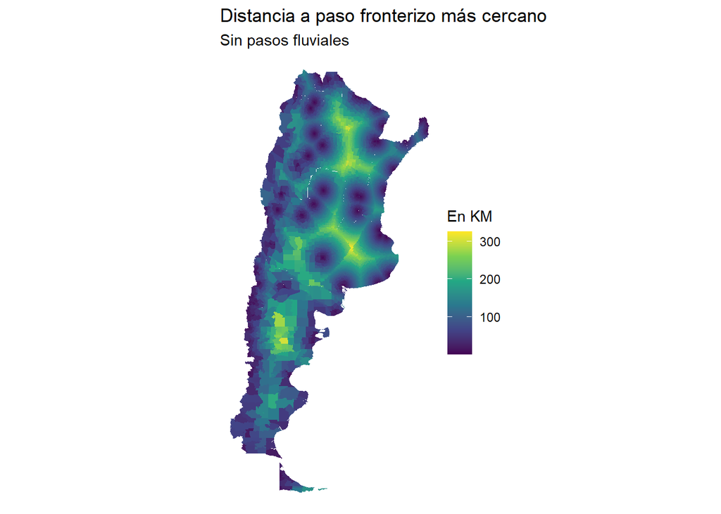

Veamos ahora la cantida de migrantes. Tenemos el siguiente archivo construido a partir del censo 2010.

```
## [1] "data.frame"
```

```
## Rows: 319,953
## Columns: 16
## $ CPV2010_REF_ID <int> 1, 1, 1, 1, 1, 1, 1, 1, 1, 1, 1, 1, 1, 1, 1, 1, 1, 1, 1~
## $ IDPROV         <int> 2, 2, 2, 2, 2, 2, 2, 2, 2, 2, 2, 2, 2, 2, 2, 2, 2, 2, 2~
## $ PROV           <int> 2, 2, 2, 2, 2, 2, 2, 2, 2, 2, 2, 2, 2, 2, 2, 2, 2, 2, 2~
## $ NOMPROV        <fct> Ciudad AutÃ³noma de Buenos Aires                   , Ci~
## $ DPTO_REF_ID    <int> 1, 1, 1, 1, 1, 1, 1, 1, 1, 1, 1, 1, 1, 1, 1, 1, 1, 1, 1~
## $ IDDPTO         <int> 1, 1, 1, 1, 1, 1, 1, 1, 1, 1, 1, 1, 1, 1, 1, 1, 1, 1, 1~
## $ DPTO           <int> 2001, 2001, 2001, 2001, 2001, 2001, 2001, 2001, 2001, 2~
## $ NOMDPTO        <fct> Comuna 01                                         , Com~
## $ FRAC_REF_ID    <int> 1, 1, 1, 1, 1, 1, 1, 1, 1, 1, 2, 2, 2, 2, 2, 2, 2, 2, 2~
## $ IDFRAC         <int> 1, 1, 1, 1, 1, 1, 1, 1, 1, 1, 2, 2, 2, 2, 2, 2, 2, 2, 2~
## $ IDRADIO        <int> 1, 1, 1, 1, 1, 1, 1, 1, 1, 1, 1, 1, 1, 1, 2, 2, 2, 2, 2~
## $ RADIO_REF_ID   <int> 1, 1, 1, 1, 1, 1, 1, 1, 1, 1, 2, 2, 2, 2, 3, 3, 3, 3, 3~
## $ extranjero     <int> 1, 2, 2, 2, 2, 2, 2, 2, 2, 2, 1, 2, 2, 2, 1, 2, 2, 2, 2~
## $ continente     <fct> america, africa, america, america, america, america, am~
## $ pais           <fct> Argentina, MARRUECOS, BOLIVIA, BRASIL, COLOMBIA, PARAGU~
## $ contar         <int> 247, 1, 8, 1, 3, 42, 30, 2, 1, 1, 394, 52, 28, 4, 299, ~
```

Creamos la clave por la cual vamos a unir las diferentes bases.

Agrupamos por radio y obtenemos la cantidad de argentinos, extranjeros y sus proporciones.

Juntamos con el dataset de radios.

Vemos correlación. Da una correlación negativa de 0.28; si bien nos indica que hay una variación conjunta de ambas variables, no deja de ser una correlación débil. Para la distancia sin pasos fluviales, la correlación es levemente superior.

```
## Correlación con distancia a pásos fronterizos:
```

```
##                 distanciaKM extranjerosProp
## distanciaKM       1.0000000      -0.2780121
## extranjerosProp  -0.2780121       1.0000000
```

```
##
## Correlación con distancia a pásos fronterizos (sin pasos fluviales):
```

```
##                 distanciaKM_sf extranjerosProp
## distanciaKM_sf       1.0000000      -0.3055061
## extranjerosProp     -0.3055061       1.0000000
```

Veamos en mapa. Radios por cantidad de extranjeros.

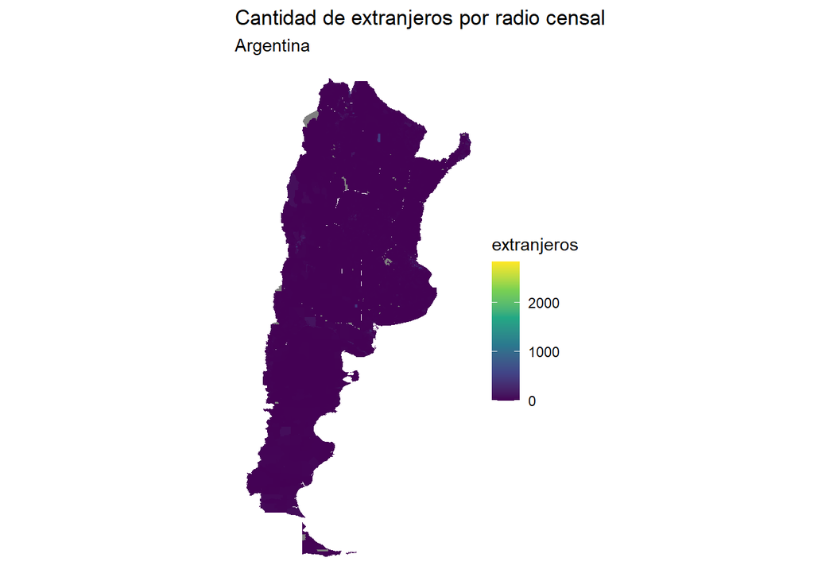

Vemos que la variable extranjeros es muy asimétrica y tiene muchos outliers. Eso dificulta nuestra visualización. Intentemos cortar la variable en categorías. Probamos diferentes tipos de cortes, nos quedamos finalmente con el algoritmo K-Means, que minimiza la diferencia entre los integrantes del mismo grupo.

Graficamos nuevamente, ahora con las categorías que nos brinda el algoritmo K-Means para encontrar los mejores puntos de quiebre en una variable.

[figure not shown]

Intentemos ver provincia por provincia, para ver más en detalle.

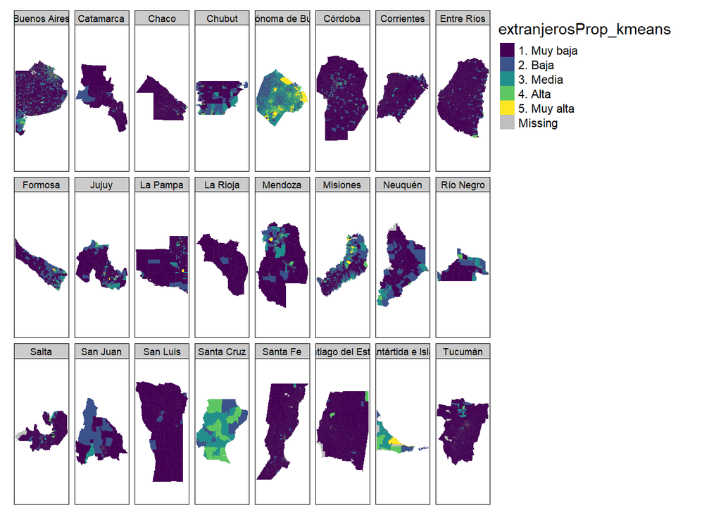

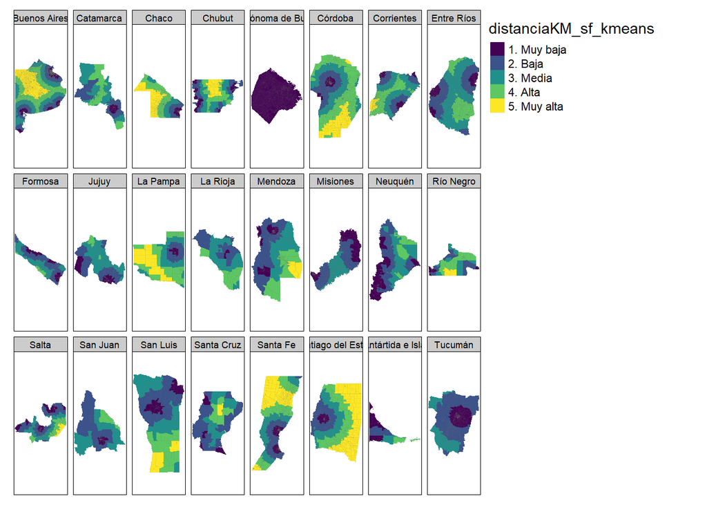

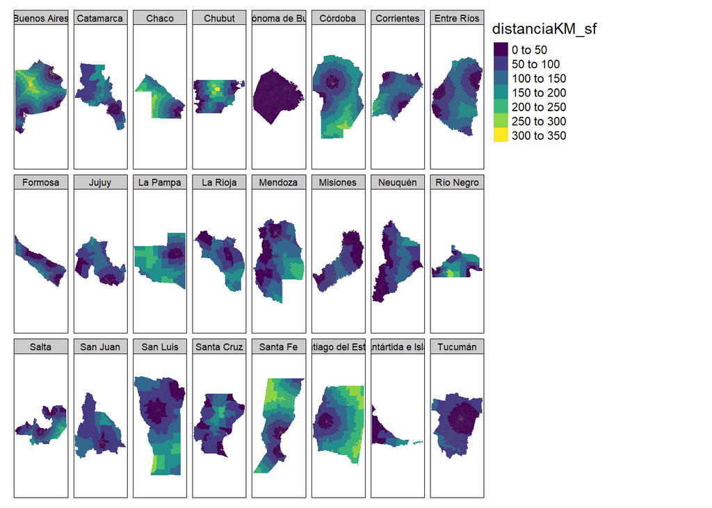

*Hipótesis*: al ser Argentina un país con un elevado nivel de urbanización, comparar todos los radios censales puede llevarnos a trabajar con lugares con muy pocos habitantes. Creemos que, si restringimos el análisis alrededor de las capitales de las provincias, puede darnos una relación algo más fuerte.

Cargamos las capitales y hacemos buffers.

```
## although coordinates are longitude/latitude, st_union assumes that they are planar
```

```
## dist is assumed to be in decimal degrees (arc_degrees).
```

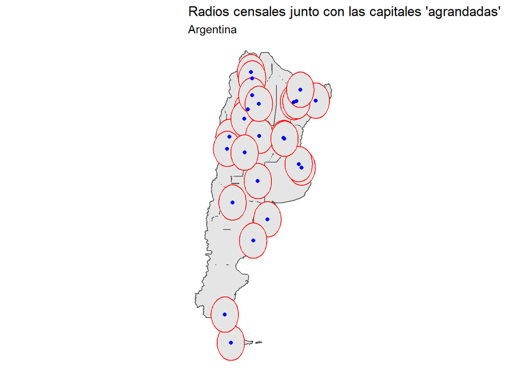

```
## dist is assumed to be in decimal degrees (arc_degrees).
```

```
## although coordinates are longitude/latitude, st_intersection assumes that they are planar
```

```
## [1] 32
```

Chequeamos la correlación esta vez sólo con los radios censales cercanos a las capitales. No vemos un crecimiento importante.

```
## Correlación sólo tomando los radios alrededor de las capitales de las provincias:
```

```
##                 distanciaKM extranjerosProp
## distanciaKM       1.0000000      -0.2813228
## extranjerosProp  -0.2813228       1.0000000
```

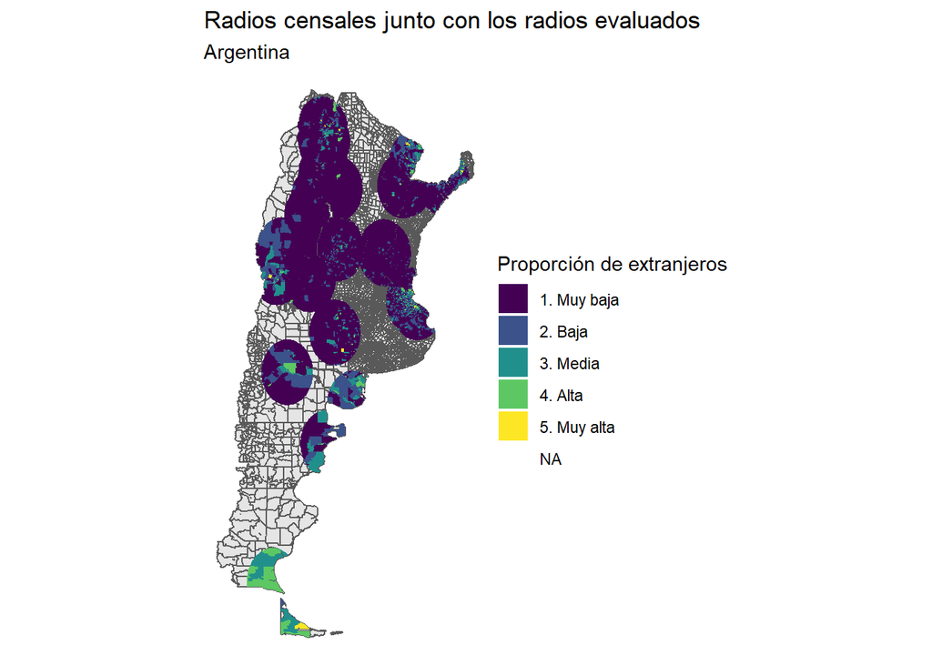

Como conclusión parcial, podemos decir que la relación es débil y en el mapa es difícil de ver, ya que la mayor proporción de extranjeros se concentra en las ciudades más pobladas y, por lo tanto, de radios más pequeños. Probablemente otras variables expliquen mejor la ubicación de los extranjeros en el país, tales como la población ya radicada, la disponibilidad de fuentes de empleo, ciertas redes internas de transporte, etc.